# Notebook

Lab: Churn Analysis

The purpose of the lab is to perform analysis of the customer base of an e-commerce site, determine the characteristics of the individuals who have stopped using the service (known as “customer churn”), and devise strategies to target similar individuals within the dataset and prevent them from changing.

1. Download the dataset from Blackboard. The .csv file contains the dataset. There is also a .xlsx file containing the data dictionary, with descriptions of what each column entails
2. Using Python tools, import the dataset as a Pandas Dataframe and perform analysis to determine the customer churn characteristics. Your analysis should include cleaning the data (as needed), X-Y Scatter plots on appropriate variable pairs, and correlation testing.  
   a. You are also permitted to use additional techniques which may not be listed, provided that you can submit a rationale for why the technique is useful and an indication of what you hope to achieve.
3. Perform decision tree and logistics regression models. a. When splitting the data into train and test data, use test_size = 0.20.
4. In a Presentation document, record your observations with respect to the customers who have already churned, and use it to identify the groups of people most likely to churn next. Devise a high-level marketing strategy to entice these individuals to continue using the service.

# **1:Import all necessary libraries**:

```python
#Import all the necessory libraries
import numpy as np # linear algebra
import pandas as pd # data processing, CSV file I/O (e.g. pd.read_csv)

import matplotlib.pyplot as plt#visualization
%matplotlib inline

import seaborn as sns#visualization
import plotly.offline as py#visualization
import plotly.graph_objs as go#visualization
import warnings
warnings.filterwarnings("ignore")
```

Data Import: Download the dataset from Blackboard. The .csv file contains the dataset. There is also a .xlsx file containing the data dictionary, with descriptions of what each column entails

# **2:Import dataset:**

```python
#2: import data
# Replace '/content/your_file_name.csv' with the actual path to your uploaded file in Colab
df = pd.read_csv('/content/E-Commerce Churn Data.csv')
```

```python
from google.colab import drive
drive.mount('/content/drive')
```

Data Overview Check out the data

What you are looking for?

look for missing values look for abnormalities Do you need to parse the data? Do you need to change the column name? Do you need to standardize data? Is there any data conflicts you need to change or remove?

```python
# data overview
df.head()
```

|  | CustomerID | Churn | Tenure | PreferredLoginDevice | CityTier | WarehouseToHome | PreferredPaymentMode | Gender | HourSpendOnApp | NumberOfDeviceRegistered | PreferedOrderCat | SatisfactionScore | MaritalStatus | NumberOfAddress | Complain | OrderAmountHikeFromlastYear | CouponUsed | OrderCount | DaySinceLastOrder | CashbackAmount |
| --- | --- | --- | --- | --- | --- | --- | --- | --- | --- | --- | --- | --- | --- | --- | --- | --- | --- | --- | --- | --- |
| 0 | 50001 | 1 | 4.0 | Mobile Phone | 3 | 6.0 | Debit Card | Female | 3.0 | 3 | Laptop & Accessory | 2 | Single | 9 | 1 | 11.0 | 1.0 | 1.0 | 5.0 | 160 |
| 1 | 50002 | 1 | NaN | Phone | 1 | 8.0 | UPI | Male | 3.0 | 4 | Mobile | 3 | Single | 7 | 1 | 15.0 | 0.0 | 1.0 | 0.0 | 121 |
| 2 | 50003 | 1 | NaN | Phone | 1 | 30.0 | Debit Card | Male | 2.0 | 4 | Mobile | 3 | Single | 6 | 1 | 14.0 | 0.0 | 1.0 | 3.0 | 120 |
| 3 | 50004 | 1 | 0.0 | Phone | 3 | 15.0 | Debit Card | Male | 2.0 | 4 | Laptop & Accessory | 5 | Single | 8 | 0 | 23.0 | 0.0 | 1.0 | 3.0 | 134 |
| 4 | 50005 | 1 | 0.0 | Phone | 1 | 12.0 | CC | Male | NaN | 3 | Mobile | 5 | Single | 3 | 0 | 11.0 | 1.0 | 1.0 | 3.0 | 130 |

```python
df.head(100)
```

|  | CustomerID | Churn | Tenure | PreferredLoginDevice | CityTier | WarehouseToHome | PreferredPaymentMode | Gender | HourSpendOnApp | NumberOfDeviceRegistered | PreferedOrderCat | SatisfactionScore | MaritalStatus | NumberOfAddress | Complain | OrderAmountHikeFromlastYear | CouponUsed | OrderCount | DaySinceLastOrder | CashbackAmount |
| --- | --- | --- | --- | --- | --- | --- | --- | --- | --- | --- | --- | --- | --- | --- | --- | --- | --- | --- | --- | --- |
| 0 | 50001 | 1 | 4.0 | Mobile Phone | 3 | 6.0 | Debit Card | Female | 3.0 | 3 | Laptop & Accessory | 2 | Single | 9 | 1 | 11.0 | 1.0 | 1.0 | 5.0 | 160 |
| 1 | 50002 | 1 | NaN | Phone | 1 | 8.0 | UPI | Male | 3.0 | 4 | Mobile | 3 | Single | 7 | 1 | 15.0 | 0.0 | 1.0 | 0.0 | 121 |
| 2 | 50003 | 1 | NaN | Phone | 1 | 30.0 | Debit Card | Male | 2.0 | 4 | Mobile | 3 | Single | 6 | 1 | 14.0 | 0.0 | 1.0 | 3.0 | 120 |
| 3 | 50004 | 1 | 0.0 | Phone | 3 | 15.0 | Debit Card | Male | 2.0 | 4 | Laptop & Accessory | 5 | Single | 8 | 0 | 23.0 | 0.0 | 1.0 | 3.0 | 134 |
| 4 | 50005 | 1 | 0.0 | Phone | 1 | 12.0 | CC | Male | NaN | 3 | Mobile | 5 | Single | 3 | 0 | 11.0 | 1.0 | 1.0 | 3.0 | 130 |
| ... | ... | ... | ... | ... | ... | ... | ... | ... | ... | ... | ... | ... | ... | ... | ... | ... | ... | ... | ... | ... |
| 95 | 50096 | 0 | 9.0 | Mobile Phone | 1 | 11.0 | Debit Card | Male | 3.0 | 3 | Laptop & Accessory | 4 | Single | 9 | 0 | 16.0 | 0.0 | 3.0 | 7.0 | 159 |
| 96 | 50097 | 0 | 6.0 | Phone | 1 | NaN | CC | Female | 2.0 | 4 | Mobile | 4 | Divorced | 7 | 0 | 21.0 | 0.0 | 1.0 | 1.0 | 126 |
| 97 | 50098 | 0 | 10.0 | Computer | 1 | 17.0 | UPI | Male | 2.0 | 3 | Fashion | 2 | Married | 2 | 1 | 14.0 | 0.0 | 1.0 | NaN | 222 |
| 98 | 50099 | 0 | 11.0 | Mobile Phone | 3 | 9.0 | Debit Card | Male | 3.0 | 3 | Fashion | 3 | Married | 1 | 0 | 12.0 | 1.0 | 5.0 | 13.0 | 206 |
| 99 | 50100 | 0 | 4.0 | Computer | 1 | 6.0 | Credit Card | Male | 2.0 | 5 | Laptop & Accessory | 3 | Divorced | 1 | 0 | 12.0 | 1.0 | 1.0 | 4.0 | 143 |

100 rows × 20 columns

```python
# shape
df.shape
```

```
(5630, 20)
```

```python
#Data Information:
df.info()
```

```
<class 'pandas.core.frame.DataFrame'>
RangeIndex: 5630 entries, 0 to 5629
Data columns (total 20 columns):
 #   Column                       Non-Null Count  Dtype
---  ------                       --------------  -----
 0   CustomerID                   5630 non-null   int64
 1   Churn                        5630 non-null   int64
 2   Tenure                       5366 non-null   float64
 3   PreferredLoginDevice         5630 non-null   object
 4   CityTier                     5630 non-null   int64
 5   WarehouseToHome              5379 non-null   float64
 6   PreferredPaymentMode         5630 non-null   object
 7   Gender                       5630 non-null   object
 8   HourSpendOnApp               5375 non-null   float64
 9   NumberOfDeviceRegistered     5630 non-null   int64
 10  PreferedOrderCat             5630 non-null   object
 11  SatisfactionScore            5630 non-null   int64
 12  MaritalStatus                5630 non-null   object
 13  NumberOfAddress              5630 non-null   int64
 14  Complain                     5630 non-null   int64
 15  OrderAmountHikeFromlastYear  5365 non-null   float64
 16  CouponUsed                   5374 non-null   float64
 17  OrderCount                   5372 non-null   float64
 18  DaySinceLastOrder            5323 non-null   float64
 19  CashbackAmount               5630 non-null   int64
dtypes: float64(7), int64(8), object(5)
memory usage: 879.8+ KB
```

```python
# columns names:
df.columns
```

```
Index(['CustomerID', 'Churn', 'Tenure', 'PreferredLoginDevice', 'CityTier',
       'WarehouseToHome', 'PreferredPaymentMode', 'Gender', 'HourSpendOnApp',
       'NumberOfDeviceRegistered', 'PreferedOrderCat', 'SatisfactionScore',
       'MaritalStatus', 'NumberOfAddress', 'Complain',
       'OrderAmountHikeFromlastYear', 'CouponUsed', 'OrderCount',
       'DaySinceLastOrder', 'CashbackAmount'],
      dtype='object')
```

# **3:Data Cleaning:**

```python
# check for the missing values:
df.isnull().sum()
```

|  | 0 |
| --- | --- |
| CustomerID | 0 |
| Churn | 0 |
| Tenure | 264 |
| PreferredLoginDevice | 0 |
| CityTier | 0 |
| WarehouseToHome | 251 |
| PreferredPaymentMode | 0 |
| Gender | 0 |
| HourSpendOnApp | 255 |
| NumberOfDeviceRegistered | 0 |
| PreferedOrderCat | 0 |
| SatisfactionScore | 0 |
| MaritalStatus | 0 |
| NumberOfAddress | 0 |
| Complain | 0 |
| OrderAmountHikeFromlastYear | 265 |
| CouponUsed | 256 |
| OrderCount | 258 |
| DaySinceLastOrder | 307 |
| CashbackAmount | 0 |

**dtype:** int64

```python
# missing values sum
df.isnull().sum().sum()
```

```
np.int64(1856)
```

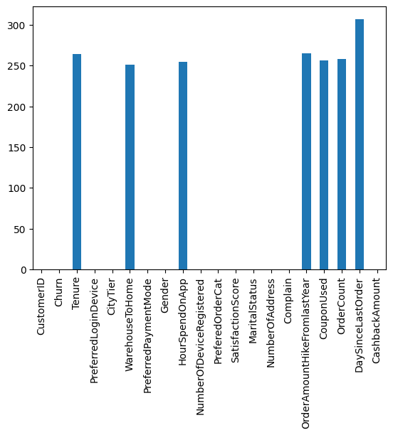

```python
#plotting the missing values
df.isna().sum().plot(kind='bar')
plt.show()
```

```python
#creating a function to display the data type, percentage of missing values and number of unique values per column
def sniff_modified(df):
    with pd.option_context("display.max_colwidth", 20):
        info = pd.DataFrame()
        info['data type'] = df.dtypes
        info['percent missing'] = df.isnull().sum()*100/len(df)
        info['No. unique'] = df.apply(lambda x: len(x.unique()))
        info['unique values'] = df.apply(lambda x: x.unique())
        return info.sort_values('data type')
```

```python
sniff_modified(df)
```

|  | data type | percent missing | No. unique | unique values |
| --- | --- | --- | --- | --- |
| CustomerID | int64 | 0.000000 | 5630 | [50001, 50002, 50003, 50004, 50005, 50006, 500... |
| Complain | int64 | 0.000000 | 2 | [1, 0] |
| NumberOfAddress | int64 | 0.000000 | 15 | [9, 7, 6, 8, 3, 2, 4, 10, 1, 5, 19, 21, 11, 20... |
| SatisfactionScore | int64 | 0.000000 | 5 | [2, 3, 5, 4, 1] |
| NumberOfDeviceRegistered | int64 | 0.000000 | 6 | [3, 4, 5, 2, 1, 6] |
| Churn | int64 | 0.000000 | 2 | [1, 0] |
| CityTier | int64 | 0.000000 | 3 | [3, 1, 2] |
| CashbackAmount | int64 | 0.000000 | 220 | [160, 121, 120, 134, 130, 139, 123, 127, 295, ... |
| WarehouseToHome | float64 | 4.458259 | 35 | [6.0, 8.0, 30.0, 15.0, 12.0, 22.0, 11.0, 9.0, ... |
| HourSpendOnApp | float64 | 4.529307 | 7 | [3.0, 2.0, nan, 1.0, 0.0, 4.0, 5.0] |
| DaySinceLastOrder | float64 | 5.452931 | 23 | [5.0, 0.0, 3.0, 7.0, 2.0, 1.0, 8.0, 6.0, 4.0, ... |
| Tenure | float64 | 4.689165 | 37 | [4.0, nan, 0.0, 13.0, 11.0, 9.0, 19.0, 20.0, 1... |
| OrderAmountHikeFromlastYear | float64 | 4.706927 | 17 | [11.0, 15.0, 14.0, 23.0, 22.0, 16.0, 12.0, nan... |
| CouponUsed | float64 | 4.547069 | 18 | [1.0, 0.0, 4.0, 2.0, 9.0, 6.0, 11.0, nan, 7.0,... |
| OrderCount | float64 | 4.582593 | 17 | [1.0, 6.0, 2.0, 15.0, 4.0, 7.0, 3.0, 9.0, nan,... |
| PreferredPaymentMode | object | 0.000000 | 7 | [Debit Card, UPI, CC, Cash on Delivery, E wall... |
| Gender | object | 0.000000 | 2 | [Female, Male] |
| PreferedOrderCat | object | 0.000000 | 6 | [Laptop & Accessory, Mobile, Mobile Phone, Oth... |
| PreferredLoginDevice | object | 0.000000 | 3 | [Mobile Phone, Phone, Computer] |
| MaritalStatus | object | 0.000000 | 3 | [Single, Divorced, Married] |

```python
#creating a function to find the columns with missing values, extract the number and percentage of these missing values in relation to the dataset

def FindMissingColsPercentage(df):

    total = 0
    for col in df.columns:
        missing_vals = df[col].isnull().sum()
        # mean = sum / total
        pct = df[col].isnull().mean() * 100
        if missing_vals != 0:
          print('{} => {} [{}%]'.format(col, df[col].isnull().sum(), round(pct, 2)))
        total += missing_vals

    if total == 0:
        print("no missing values")
```

```python
FindMissingColsPercentage(df)
```

```
Tenure => 264 [4.69%]
WarehouseToHome => 251 [4.46%]
HourSpendOnApp => 255 [4.53%]
OrderAmountHikeFromlastYear => 265 [4.71%]
CouponUsed => 256 [4.55%]
OrderCount => 258 [4.58%]
DaySinceLastOrder => 307 [5.45%]
```

```python
# replace missing values with the mean of each column
for column in ['Tenure', 'WarehouseToHome', 'HourSpendOnApp', 'OrderAmountHikeFromlastYear', 'CouponUsed', 'OrderCount', 'DaySinceLastOrder']:
    df[column].fillna(df[column].mean(), inplace=True)
```

```python
# again, checking for missing values:
df.isnull().sum()
```

|  | 0 |
| --- | --- |
| CustomerID | 0 |
| Churn | 0 |
| Tenure | 0 |
| PreferredLoginDevice | 0 |
| CityTier | 0 |
| WarehouseToHome | 0 |
| PreferredPaymentMode | 0 |
| Gender | 0 |
| HourSpendOnApp | 0 |
| NumberOfDeviceRegistered | 0 |
| PreferedOrderCat | 0 |
| SatisfactionScore | 0 |
| MaritalStatus | 0 |
| NumberOfAddress | 0 |
| Complain | 0 |
| OrderAmountHikeFromlastYear | 0 |
| CouponUsed | 0 |
| OrderCount | 0 |
| DaySinceLastOrder | 0 |
| CashbackAmount | 0 |

**dtype:** int64

```python
# or...# duplicates
df = df.drop_duplicates()
```

```python
# data
df.head()
```

|  | CustomerID | Churn | Tenure | PreferredLoginDevice | CityTier | WarehouseToHome | PreferredPaymentMode | Gender | HourSpendOnApp | NumberOfDeviceRegistered | PreferedOrderCat | SatisfactionScore | MaritalStatus | NumberOfAddress | Complain | OrderAmountHikeFromlastYear | CouponUsed | OrderCount | DaySinceLastOrder | CashbackAmount |
| --- | --- | --- | --- | --- | --- | --- | --- | --- | --- | --- | --- | --- | --- | --- | --- | --- | --- | --- | --- | --- |
| 0 | 50001 | 1 | 4.000000 | Mobile Phone | 3 | 6.0 | Debit Card | Female | 3.000000 | 3 | Laptop & Accessory | 2 | Single | 9 | 1 | 11.0 | 1.0 | 1.0 | 5.0 | 160 |
| 1 | 50002 | 1 | 10.189899 | Phone | 1 | 8.0 | UPI | Male | 3.000000 | 4 | Mobile | 3 | Single | 7 | 1 | 15.0 | 0.0 | 1.0 | 0.0 | 121 |
| 2 | 50003 | 1 | 10.189899 | Phone | 1 | 30.0 | Debit Card | Male | 2.000000 | 4 | Mobile | 3 | Single | 6 | 1 | 14.0 | 0.0 | 1.0 | 3.0 | 120 |
| 3 | 50004 | 1 | 0.000000 | Phone | 3 | 15.0 | Debit Card | Male | 2.000000 | 4 | Laptop & Accessory | 5 | Single | 8 | 0 | 23.0 | 0.0 | 1.0 | 3.0 | 134 |
| 4 | 50005 | 1 | 0.000000 | Phone | 1 | 12.0 | CC | Male | 2.931535 | 3 | Mobile | 5 | Single | 3 | 0 | 11.0 | 1.0 | 1.0 | 3.0 | 130 |

```python
# OR for handling missing or spaces
# after looking at the data, we have found that there are spaces instad of missing value
# replacing " " or any missing values with np.nan
df = df.replace(" ", np.nan)
```

```python
# checking data
df.head()
```

|  | CustomerID | Churn | Tenure | PreferredLoginDevice | CityTier | WarehouseToHome | PreferredPaymentMode | Gender | HourSpendOnApp | NumberOfDeviceRegistered | PreferedOrderCat | SatisfactionScore | MaritalStatus | NumberOfAddress | Complain | OrderAmountHikeFromlastYear | CouponUsed | OrderCount | DaySinceLastOrder | CashbackAmount |
| --- | --- | --- | --- | --- | --- | --- | --- | --- | --- | --- | --- | --- | --- | --- | --- | --- | --- | --- | --- | --- |
| 0 | 50001 | 1 | 4.000000 | Mobile Phone | 3 | 6.0 | Debit Card | Female | 3.000000 | 3 | Laptop & Accessory | 2 | Single | 9 | 1 | 11.0 | 1.0 | 1.0 | 5.0 | 160 |
| 1 | 50002 | 1 | 10.189899 | Phone | 1 | 8.0 | UPI | Male | 3.000000 | 4 | Mobile | 3 | Single | 7 | 1 | 15.0 | 0.0 | 1.0 | 0.0 | 121 |
| 2 | 50003 | 1 | 10.189899 | Phone | 1 | 30.0 | Debit Card | Male | 2.000000 | 4 | Mobile | 3 | Single | 6 | 1 | 14.0 | 0.0 | 1.0 | 3.0 | 120 |
| 3 | 50004 | 1 | 0.000000 | Phone | 3 | 15.0 | Debit Card | Male | 2.000000 | 4 | Laptop & Accessory | 5 | Single | 8 | 0 | 23.0 | 0.0 | 1.0 | 3.0 | 134 |
| 4 | 50005 | 1 | 0.000000 | Phone | 1 | 12.0 | CC | Male | 2.931535 | 3 | Mobile | 5 | Single | 3 | 0 | 11.0 | 1.0 | 1.0 | 3.0 | 130 |

```python
# again checking for null
df.isnull().sum()
```

|  | 0 |
| --- | --- |
| CustomerID | 0 |
| Churn | 0 |
| Tenure | 0 |
| PreferredLoginDevice | 0 |
| CityTier | 0 |
| WarehouseToHome | 0 |
| PreferredPaymentMode | 0 |
| Gender | 0 |
| HourSpendOnApp | 0 |
| NumberOfDeviceRegistered | 0 |
| PreferedOrderCat | 0 |
| SatisfactionScore | 0 |
| MaritalStatus | 0 |
| NumberOfAddress | 0 |
| Complain | 0 |
| OrderAmountHikeFromlastYear | 0 |
| CouponUsed | 0 |
| OrderCount | 0 |
| DaySinceLastOrder | 0 |
| CashbackAmount | 0 |

**dtype:** int64

```python
FindMissingColsPercentage(df)
```

```
no missing values
```

```python
# Convert categorical columns to numeric using one-hot encoding
categorical_cols = ['PreferredLoginDevice', 'PreferredPaymentMode', 'Gender', 'PreferedOrderCat', 'MaritalStatus']
df = pd.get_dummies(df, columns=categorical_cols, drop_first=True)

display(df.head())
```

|  | CustomerID | Churn | Tenure | CityTier | WarehouseToHome | HourSpendOnApp | NumberOfDeviceRegistered | SatisfactionScore | NumberOfAddress | Complain | ... | PreferredPaymentMode_E wallet | PreferredPaymentMode_UPI | Gender_Male | PreferedOrderCat_Grocery | PreferedOrderCat_Laptop & Accessory | PreferedOrderCat_Mobile | PreferedOrderCat_Mobile Phone | PreferedOrderCat_Others | MaritalStatus_Married | MaritalStatus_Single |
| --- | --- | --- | --- | --- | --- | --- | --- | --- | --- | --- | --- | --- | --- | --- | --- | --- | --- | --- | --- | --- | --- |
| 0 | 50001 | 1 | 4.000000 | 3 | 6.0 | 3.000000 | 3 | 2 | 9 | 1 | ... | False | False | False | False | True | False | False | False | False | True |
| 1 | 50002 | 1 | 10.189899 | 1 | 8.0 | 3.000000 | 4 | 3 | 7 | 1 | ... | False | True | True | False | False | True | False | False | False | True |
| 2 | 50003 | 1 | 10.189899 | 1 | 30.0 | 2.000000 | 4 | 3 | 6 | 1 | ... | False | False | True | False | False | True | False | False | False | True |
| 3 | 50004 | 1 | 0.000000 | 3 | 15.0 | 2.000000 | 4 | 5 | 8 | 0 | ... | False | False | True | False | True | False | False | False | False | True |
| 4 | 50005 | 1 | 0.000000 | 1 | 12.0 | 2.931535 | 3 | 5 | 3 | 0 | ... | False | False | True | False | False | True | False | False | False | True |

5 rows × 31 columns

```python
# data type checking:
df.dtypes
```

|  | 0 |
| --- | --- |
| CustomerID | int64 |
| Churn | int64 |
| Tenure | float64 |
| CityTier | int64 |
| WarehouseToHome | float64 |
| HourSpendOnApp | float64 |
| NumberOfDeviceRegistered | int64 |
| SatisfactionScore | int64 |
| NumberOfAddress | int64 |
| Complain | int64 |
| OrderAmountHikeFromlastYear | float64 |
| CouponUsed | float64 |
| OrderCount | float64 |
| DaySinceLastOrder | float64 |
| CashbackAmount | int64 |
| PreferredLoginDevice_Mobile Phone | bool |
| PreferredLoginDevice_Phone | bool |
| PreferredPaymentMode_COD | bool |
| PreferredPaymentMode_Cash on Delivery | bool |
| PreferredPaymentMode_Credit Card | bool |
| PreferredPaymentMode_Debit Card | bool |
| PreferredPaymentMode_E wallet | bool |
| PreferredPaymentMode_UPI | bool |
| Gender_Male | bool |
| PreferedOrderCat_Grocery | bool |
| PreferedOrderCat_Laptop & Accessory | bool |
| PreferedOrderCat_Mobile | bool |
| PreferedOrderCat_Mobile Phone | bool |
| PreferedOrderCat_Others | bool |
| MaritalStatus_Married | bool |
| MaritalStatus_Single | bool |

**dtype:** object

```python
# data:
df.head()
```

|  | CustomerID | Churn | Tenure | CityTier | WarehouseToHome | HourSpendOnApp | NumberOfDeviceRegistered | SatisfactionScore | NumberOfAddress | Complain | ... | PreferredPaymentMode_E wallet | PreferredPaymentMode_UPI | Gender_Male | PreferedOrderCat_Grocery | PreferedOrderCat_Laptop & Accessory | PreferedOrderCat_Mobile | PreferedOrderCat_Mobile Phone | PreferedOrderCat_Others | MaritalStatus_Married | MaritalStatus_Single |
| --- | --- | --- | --- | --- | --- | --- | --- | --- | --- | --- | --- | --- | --- | --- | --- | --- | --- | --- | --- | --- | --- |
| 0 | 50001 | 1 | 4.000000 | 3 | 6.0 | 3.000000 | 3 | 2 | 9 | 1 | ... | False | False | False | False | True | False | False | False | False | True |
| 1 | 50002 | 1 | 10.189899 | 1 | 8.0 | 3.000000 | 4 | 3 | 7 | 1 | ... | False | True | True | False | False | True | False | False | False | True |
| 2 | 50003 | 1 | 10.189899 | 1 | 30.0 | 2.000000 | 4 | 3 | 6 | 1 | ... | False | False | True | False | False | True | False | False | False | True |
| 3 | 50004 | 1 | 0.000000 | 3 | 15.0 | 2.000000 | 4 | 5 | 8 | 0 | ... | False | False | True | False | True | False | False | False | False | True |
| 4 | 50005 | 1 | 0.000000 | 1 | 12.0 | 2.931535 | 3 | 5 | 3 | 0 | ... | False | False | True | False | False | True | False | False | False | True |

5 rows × 31 columns

# **4: EDA:**

**Exploratory Data Analysis**:This is crucial for understanding the data, identifying patterns, and gaining insights into the factors that might be related to customer churn.

```
array([[<Axes: title={'center': 'HourSpendOnApp'}>,
        <Axes: title={'center': 'NumberOfDeviceRegistered'}>],
       [<Axes: title={'center': 'SatisfactionScore'}>,
        <Axes: title={'center': 'OrderAmountHikeFromlastYear'}>],
       [<Axes: title={'center': 'CouponUsed'}>,
        <Axes: title={'center': 'DaySinceLastOrder'}>]], dtype=object)
```

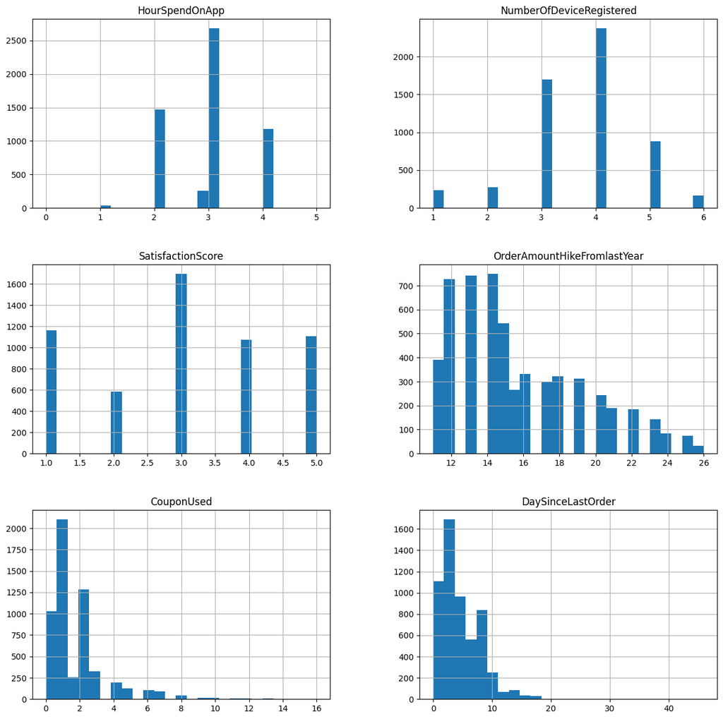

```python
# Plotting graphs for better understanding of data distribution

cols = ['HourSpendOnApp', 'NumberOfDeviceRegistered', 'SatisfactionScore', 'OrderAmountHikeFromlastYear', 'CouponUsed', 'DaySinceLastOrder']
df[cols].hist(figsize=(15,15), bins=25)
```

```python
#checking out churn rate by gender distribution using a pivot table
pd.pivot_table(df, index='Gender_Male', values='Churn', aggfunc='mean')
```

| Gender_Male | Churn |
| --- | --- |
| False | 0.154942 |
| True | 0.177305 |

## Plot 1: Pie-Chart; Customer churn rate:

To visualize the churn rate of customers in percentages, for better understanding.

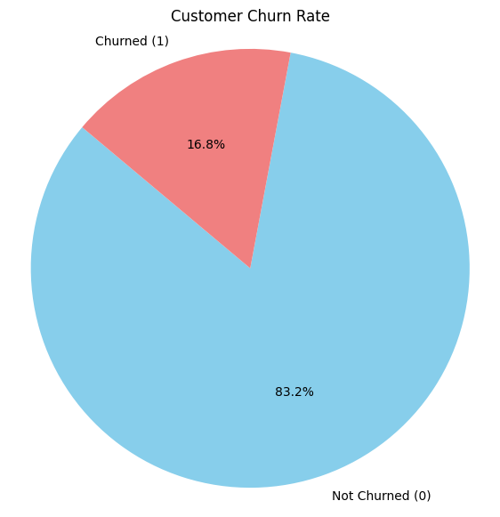

```python
# creating pie chart for ploting the customer churn rate:
# Calculate the counts of churned and non-churned customers
churn_counts = df['Churn'].value_counts()

# Create a pie chart
plt.figure(figsize=(7, 7))
plt.pie(churn_counts, labels=['Not Churned (0)', 'Churned (1)'], autopct='%1.1f%%', startangle=140, colors=['skyblue', 'lightcoral'])
plt.title('Customer Churn Rate')
plt.axis('equal') # Equal aspect ratio ensures that pie is drawn as a circle.
plt.show()
```

**Insights for the Plot 1** My analysis is showing that there are 83.2% of customers who have stayed with the company. while, only 16.8% are churned in the company.So, 1 indicates a churned customer and 0 indicates not churned customer.